# R Notebook

*8. In the lab, a classification tree was applied to the Carseats data set after converting Sales into a qualitative response variable. Now we will seek to predict Sales using regression trees and related approaches, treating the response as a quantitative variable.*

1. Split the data set into a training set and a test set.

```r
library(ISLR)
attach(Carseats)
set.seed(1)

train = sample(dim(Carseats)[1], dim(Carseats)[1]/2)
Carseats.train = Carseats[train, ]
Carseats.test = Carseats[-train, ]
```

2. Fit a regression tree to the training set. Plot the tree, and interpret the results. What test MSE do you obtain?

```r
library(tree)
tree.carseats = tree(Sales ~ ., data = Carseats.train)
summary(tree.carseats)
```

```
Regression tree:
tree(formula = Sales ~ ., data = Carseats.train)
Variables actually used in tree construction:
[1] "ShelveLoc"   "Price"       "Age"         "Advertising" "CompPrice"   "US"
Number of terminal nodes:  18
Residual mean deviance:  2.167 = 394.3 / 182
Distribution of residuals:
    Min.  1st Qu.   Median     Mean  3rd Qu.     Max.
-3.88200 -0.88200 -0.08712  0.00000  0.89590  4.09900
```

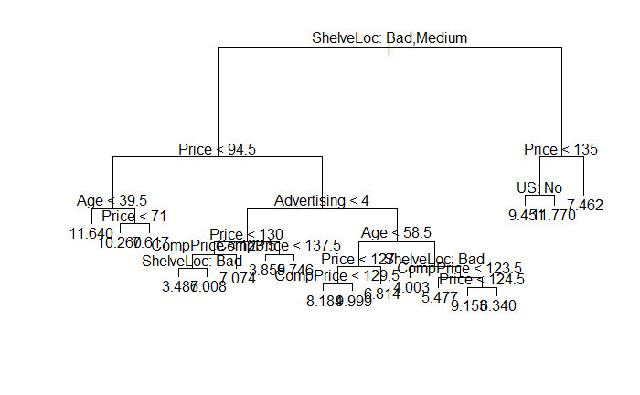

```r
plot(tree.carseats)
text(tree.carseats, pretty = 0)
```

```r
pred.carseats = predict(tree.carseats, Carseats.test)
mean((Carseats.test$Sales - pred.carseats)^2)
```

```
[1] 4.922039
```

The test MSE is about 4.92.

3. Use cross-validation in order to determine the optimal level of tree complexity. Does pruning the tree improve the test MSE?

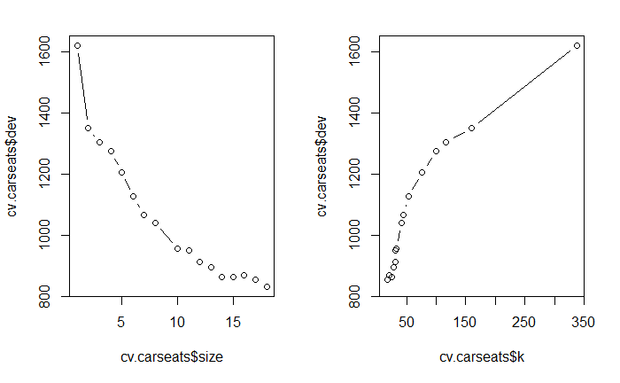

```r
cv.carseats = cv.tree(tree.carseats, FUN = prune.tree)
par(mfrow = c(1, 2))
plot(cv.carseats$size, cv.carseats$dev, type = "b")
plot(cv.carseats$k, cv.carseats$dev, type = "b")
```

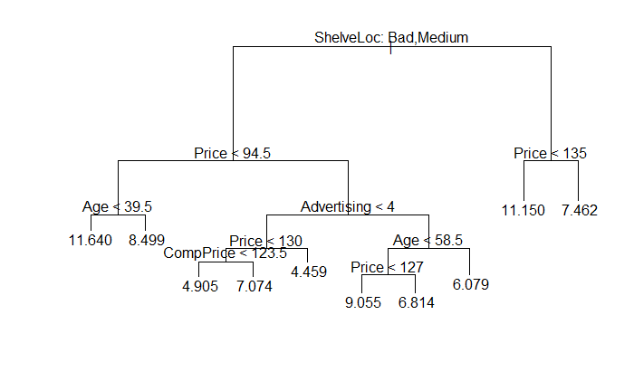

```r
# Best size = 9
pruned.carseats = prune.tree(tree.carseats, best = 9)
par(mfrow = c(1, 1))
plot(pruned.carseats)
text(pruned.carseats, pretty = 0)
```

```r
pred.pruned = predict(pruned.carseats, Carseats.test)
mean((Carseats.test$Sales - pred.pruned)^2)
```

```
[1] 4.918134
```

4. Use the bagging approach in order to analyze this data. What test MSE do you obtain? Use the importance() function to determine which variables are most important.

```r
library(randomForest)
```

```r
bag.carseats = randomForest(Sales ~ ., data = Carseats.train, mtry = 10, ntree = 500,
    importance = T)
bag.pred = predict(bag.carseats, Carseats.test)
mean((Carseats.test$Sales - bag.pred)^2)
```

```
[1] 2.657296
```

```r
importance(bag.carseats)
```

```
                %IncMSE IncNodePurity
CompPrice   23.07909904    171.185734
Income       2.82081527     94.079825
Advertising 11.43295625     99.098941
Population  -3.92119532     59.818905
Price       54.24314632    505.887016
ShelveLoc   46.26912996    361.962753
Age         14.24992212    159.740422
Education   -0.07662320     46.738585
Urban        0.08530119      8.453749
US           4.34349223     15.157608
```

5. Use random forests to analyze this data. What test MSE do you obtain? Use the importance() function to determine which variables are most important. Describe the effect of m, the number of variables considered at each split, on the error rate obtained.

```r
rf.carseats = randomForest(Sales ~ ., data = Carseats.train, mtry = 5, ntree = 500,
    importance = T)
rf.pred = predict(rf.carseats, Carseats.test)
mean((Carseats.test$Sales - rf.pred)^2)
```

```
[1] 2.701665
```

```r
importance(rf.carseats)
```

```
               %IncMSE IncNodePurity
CompPrice   19.8160444     162.73603
Income       2.8940268     106.96093
Advertising 11.6799573     106.30923
Population  -1.6998805      79.04937
Price       46.3454015     448.33554
ShelveLoc   40.4412189     334.33610
Age         12.5440659     169.06125
Education    1.0762096      55.87510
Urban        0.5703583      13.21963
US           5.8799999      25.59797
```

*10. We now use boosting to predict Salary in the Hitters data set.*

1. Remove the observations for whom the salary information is unknown, and then log-transform the salaries.

```r
library(ISLR)
sum(is.na(Hitters$Salary))
```

```
[1] 59
```

```r
Hitters = Hitters[-which(is.na(Hitters$Salary)), ]
sum(is.na(Hitters$Salary))
```

```
[1] 0
```

```r
Hitters$Salary = log(Hitters$Salary)
```

2. Create a training set consisting of the first 200 observations, and a test set consisting of the remaining observations.

```r
train = 1:200
Hitters.train = Hitters[train, ]
Hitters.test = Hitters[-train, ]
```

3. Perform boosting on the training set with 1,000 trees for a range of values of the shrinkage parameter λ. Produce a plot with different shrinkage values on the x-axis and the corresponding training set MSE on the y-axis.

```r
library(gbm)
```

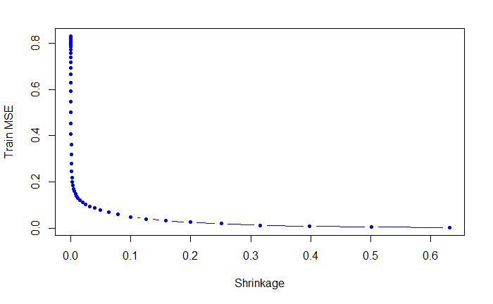

```r
set.seed(103)
pows = seq(-10, -0.2, by = 0.1)
lambdas = 10^pows
length.lambdas = length(lambdas)
train.errors = rep(NA, length.lambdas)
test.errors = rep(NA, length.lambdas)
for (i in 1:length.lambdas) {
    boost.hitters = gbm(Salary ~ ., data = Hitters.train, distribution = "gaussian",
        n.trees = 1000, shrinkage = lambdas[i])
    train.pred = predict(boost.hitters, Hitters.train, n.trees = 1000)
    test.pred = predict(boost.hitters, Hitters.test, n.trees = 1000)
    train.errors[i] = mean((Hitters.train$Salary - train.pred)^2)
    test.errors[i] = mean((Hitters.test$Salary - test.pred)^2)
}

plot(lambdas, train.errors, type = "b", xlab = "Shrinkage", ylab = "Train MSE",
    col = "blue", pch = 20)
```

4. Produce a plot with different shrinkage values on the x-axis and the corresponding test set MSE on the y-axis.

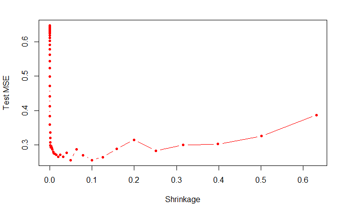

```r
plot(lambdas, test.errors, type = "b", xlab = "Shrinkage", ylab = "Test MSE", col = "red", pch = 20)
```

```r
min(test.errors)
```

```
[1] 0.2560507
```

```r
lambdas[which.min(test.errors)]
```

```
[1] 0.05011872
```

Minimum test error is obtained at λ=0.05.

5. Compare the test MSE of boosting to the test MSE that results from applying two of the regression approaches seen in Chapters 3 and 6.

```r
lm.fit = lm(Salary ~ ., data = Hitters.train)
lm.pred = predict(lm.fit, Hitters.test)
mean((Hitters.test$Salary - lm.pred)^2)
```

```
[1] 0.4917959
```

```r
library(glmnet)
```

```r
set.seed(134)
x = model.matrix(Salary ~ ., data = Hitters.train)
y = Hitters.train$Salary
x.test = model.matrix(Salary ~ ., data = Hitters.test)
lasso.fit = glmnet(x, y, alpha = 1)
lasso.pred = predict(lasso.fit, s = 0.01, newx = x.test)
mean((Hitters.test$Salary - lasso.pred)^2)
```

```
[1] 0.4700537
```

Both linear model and regularization like Lasso have higher test MSE than boosting.

6. Which variables appear to be the most important predictors in the boosted model?

|  | var | rel.inf |
| --- | --- | --- |
| CAtBat | CAtBat | 22.7562681 |
| CWalks | CWalks | 10.4279674 |
| CHits | CHits | 8.6198109 |
| PutOuts | PutOuts | 6.6159325 |
| Years | Years | 6.4611683 |
| Walks | Walks | 6.2331148 |
| CRBI | CRBI | 6.0926744 |
| CHmRun | CHmRun | 5.1076104 |
| RBI | RBI | 4.5321678 |
| CRuns | CRuns | 4.4728132 |

[output cut: 9 more lines]

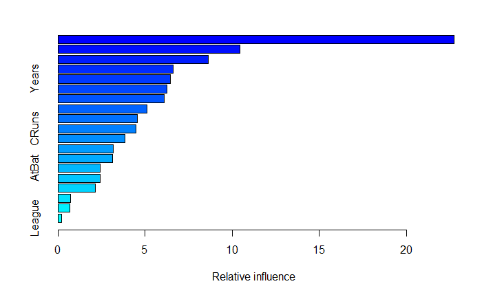

```r
boost.best = gbm(Salary ~ ., data = Hitters.train, distribution = "gaussian",
    n.trees = 1000, shrinkage = lambdas[which.min(test.errors)])
summary(boost.best)
```

7. Now apply bagging to the training set. What is the test set MSE for this approach?

```r
library(randomForest)
```

```r
set.seed(21)
rf.hitters = randomForest(Salary ~ ., data = Hitters.train, ntree = 500, mtry = 19)
rf.pred = predict(rf.hitters, Hitters.test)
mean((Hitters.test$Salary - rf.pred)^2)
```

```
[1] 0.2303919
```

Test MSE for bagging is about 0.23, which is slightly lower than the best test MSE for boosting.